# PyData London News December 2022

# POTM (Package Of The Month)

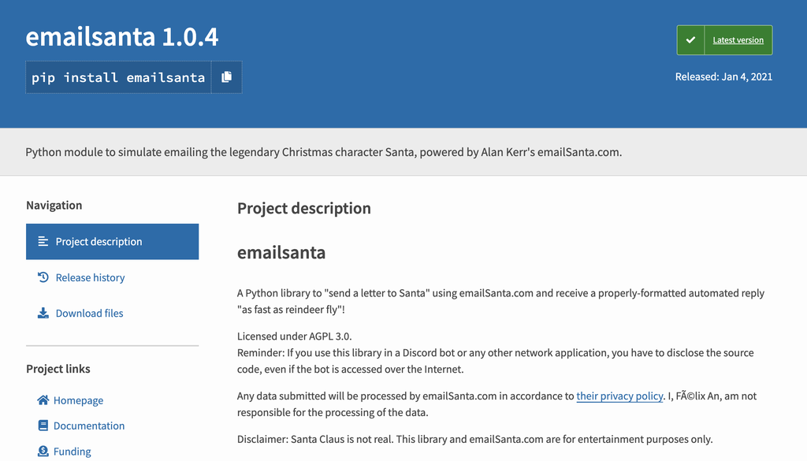

[output not shown]

# CFPOTM (CFP Of The Month)

## [Python Deadlin.es](https://pythondeadlin.es/)

[interactive chart not shown]

# Tonight's Schedule

#### 18:30 Doors open

#### 19:00 Talks start ⬅️ **YOU ARE HERE**

#### 19:15 What's the Itch That Feature Stores Scratch? — Moritz Meister

#### 19:45 Break 🥂

#### 20:00 Using BERT for Stable, Dynamic Topic Detection — Matt Hobby

#### 20:30 ⚡ Lightning Talks ⚡ + 📣 Community Announcements 📣

#### 20:45 to 21:00 We're done 🔜 The Oyster Shed 🍻

### What's the Itch That Feature Stores Scratch? — Moritz Meister

Do you actually need a feature store for machine learning (ML)? Many individuals and organizations ask themselves this question, and many come to different conclusions. In this talk, we will clearly define how a feature store solves problems such as training-inference skew for operational ML systems, reuse of pre-computed features across multiple models, and the integration of historical and contextual data into online models. However, there are also scenarios where you do not need a feature store. For example, if you have a batch system processing data in a data warehouse and the features are reused in other models. We will try to give an honest appraisal of when you should reach for the feature store tool, and when to leave well alone.

### Using BERT for Stable, Dynamic Topic Detection — Matt Hobby

BERT and other transformer models have revolutionised NLP and high dimensional representation of semantic meaning. In this talk we discuss the use of BERT embeddings to detect topics in documents. We demonstrate that the combination of BERT embeddings with network community detection methods provides a stable means of detecting topics where the number of topics apriori is unknown, this overcoming one of major shortcomings of LDA.

We highlight the stability of the methodology when compared to the approach taken by the popular BERTopic GitHub repository. Furthermore, we demonstrate how this approach can be used for dynamic topic modelling.